# Python-Dissociation Tutorial

### 1. Setup

We need to tell python where to look for the dissociation.py module. By appending the directory of the file's location to your path environment variable.

Path to **dissociation.py** on this server:

```
/usr/local/uvml-code/Dissociation/
```

```python
import sys
```

```python
sys.path.append('/usr/local/uvml-code/Dissociation/')
```

We can use an import statement to include the module:

```python
import dissociation as d
```

With the line above we have also named the dissociation module **`d`**

Additionally we want any plots we generate to show in the notebook, so we can run the following:

*(matplotlib is an incredibly valuable plotting package)*

```python
%matplotlib inline
```

The package `scikit-rf` or `skrf` has useful built-in styling that we can use as well:

```python
import skrf as rf
rf.stylely()
rf.stylely()
```

### 2. Creating a `SpectrumDataFile` object

The SpectrumDataFile class is a representation of the files that the spectrometer generates. This code will only work if the files are in the same format as the spectrometer output files. The naming convention is VERY important as well. **You must pass the path to the data file on creation.** *More on this shortly*...

Since the datafiles must be accessible to this server locally, I would recommend uploading the files to your notebook tree (the page that comes up after you start your server) using the jupyter interface.

> A better, but slightly more complicated way to upload files to the server would be through a combination of ssh and GitHub. If you would rather do this (or are just curious), let me know and I'll set that up for you/show you how to do it. For the purposed of this tutorial, I have uploaded some sample data files with current as the varying parameter.

In order to make a `SpectrumDataFile` we must call the class constructor and pass the path to the desired spectrum file. One thing to note is that I am giving the *relative* path to the spectrum file (the path from the current working directory to the file). In this case, I have all the files in a folder called `sample_data`.

```python
sdf = d.SpectrumDataFile('sample_data/500W_5p0mT_4p0A.txt')
```

`sdf` is now our `SpectrumDataFile` object, and we can use it to call various methods that analyze the raw data.

#### 2.1 Operations on `SpectrumDataFile` objects

If you want to see the raw data, for example, you can do the following:

```python
sdf.data_points[0]
```

```
(740.0, 0.27743725344351544)
```

The format is (wavelength, intensity). `[0]` is indexing the list. If you want to see all of the data points just type:

```
sdf.data_points
```

To plot the spectrum:

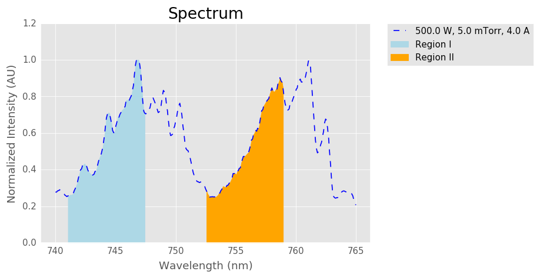

```python
sdf.plot_spectrum()
```

The highlighted regions denote the data that is used to calculate the relative dissociation, which is also contained in the `SpectrumDataFile` object.

```python
sdf.dissociation
```

```
0.22039723985873338
```

You can turn this off with the *fill* argument. You can also filter/smooth the spectrum with the *filtered* and *frac* arguments. *frac* is essentially the degree to which the data is filtered.

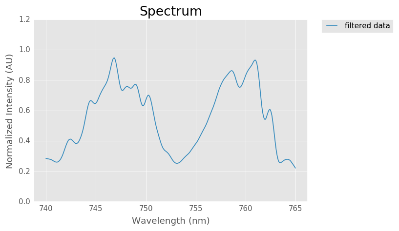

```python
sdf.plot_spectrum(fill=False, filtered=True, frac=0.05)
```

You can also plot region I - region II to see the nitrogen triplet peaks

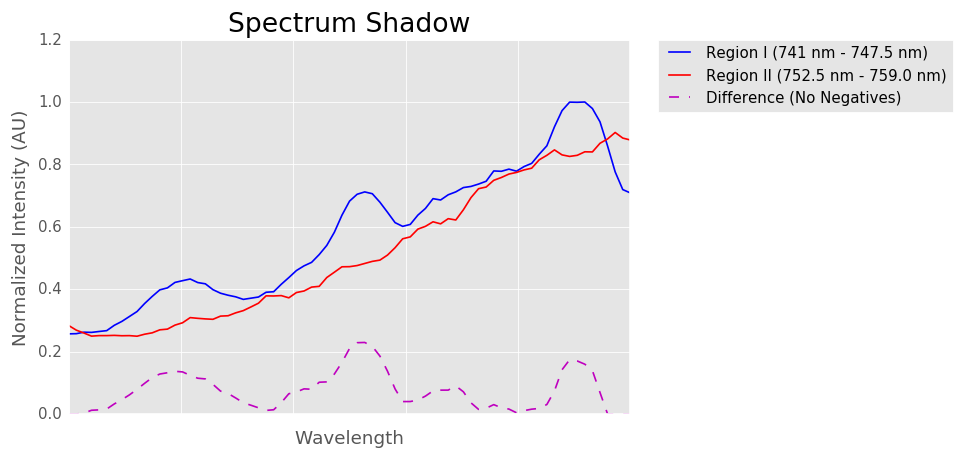

```python
sdf.plot_difference()
```

#### 2.2 Other Options

Below is the constructor for the `SpectrumDataFile` class

[output not shown]

You can change any of these on creation of the object; however, you can also change these parameters at any time after the object has been created. For example:

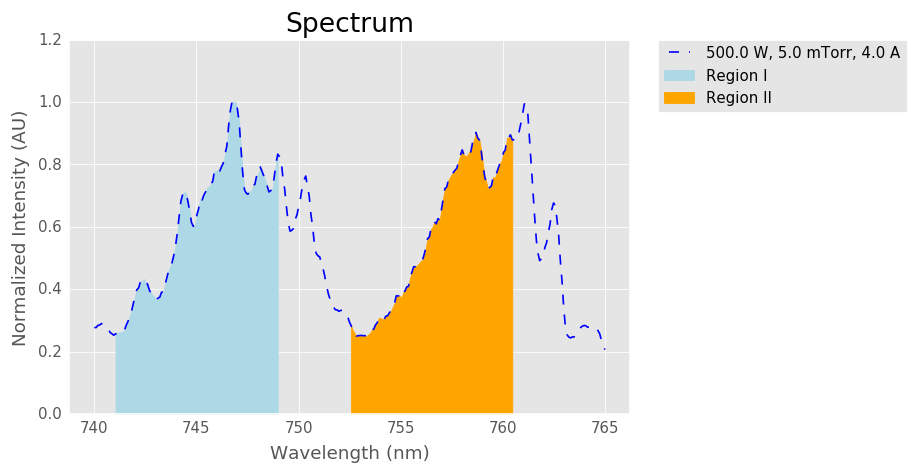

```python
sdf.spacing = 8
sdf.plot_spectrum()
```

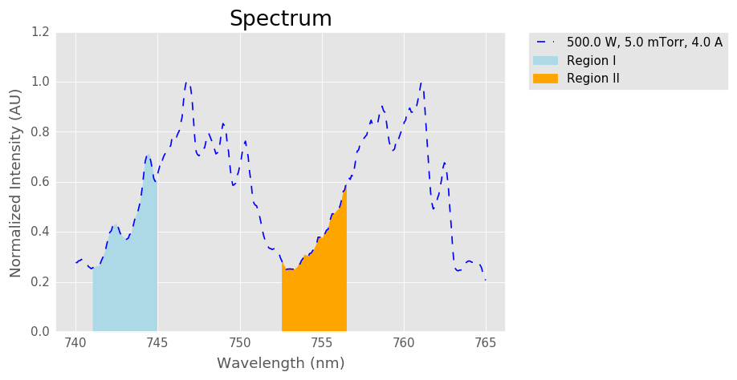

```python
sdf.spacing = 4
sdf.plot_spectrum()
```

**Note:** the default values are optimized

### 3. Creating a `SpectrumDataSet` object

The `SpectrtumDataSet` object is essentially a container for multiple `SpectrumDataFile` objects. On creation, you need to pass the path to a directory of spectrometer files. In order for the data to make sense, make sure that the files only vary one parameter (power, pressure, or current).

```python
sds = d.SpectrumDataSet('sample_data/current_set_1/')
```

After creating the data set, we need to create a `SpectrumDataFile` object for every file in the directory and calculate their respective dissociations.

```python
sds.compile_dataset()
```

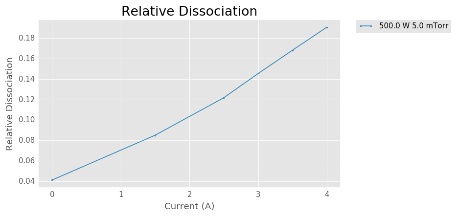

```python
sds.plot_dissociation()
```

#### 3.1 `SpectrumDataSet` Options

Shown below is the `plot_dissociation` method declaration:

```
def plot_dissociation(self, ax=None, save=False, ind_var='current', spectrum=False,
                          shadow=False, f=-1, region1=741, region2=752.5, spacing=6.5, fit=False, degree=5,
                          labeloverride=None):
```

Here it is again with the regions shifted (`region1` and `region2` arguments). To visualize, it may be useful to plot the spectrum of one of the `SpectrumDataFile` objects. To do that we can use the `spectrum` and/or `shadow` arguments (use `f` argument to choose which data file).

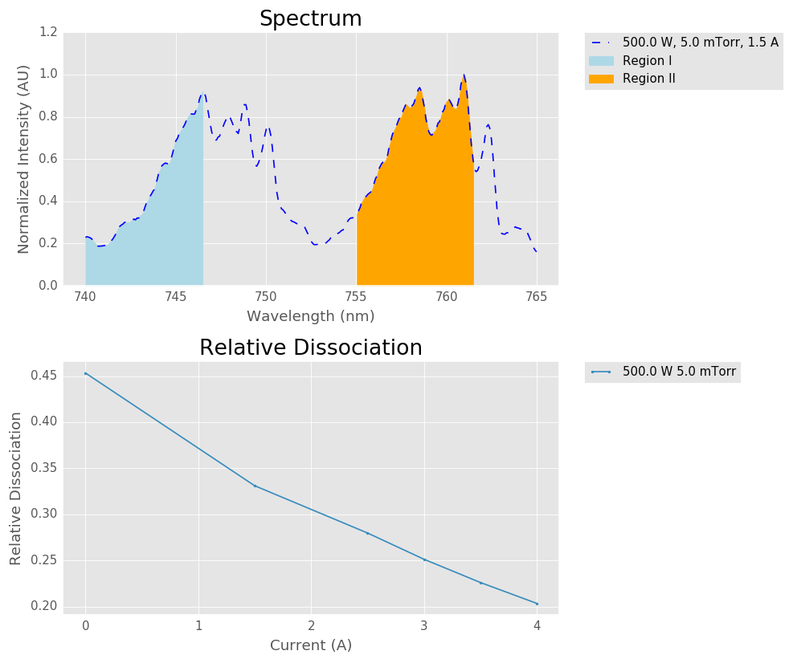

```python
sds.plot_dissociation(spectrum=True, region1=740, region2=755)
```

**But again, the parameters are already fairly well optimized.**

We can also plot a polynomial fit and choose the degree with the `fit` and `degree` arguments.

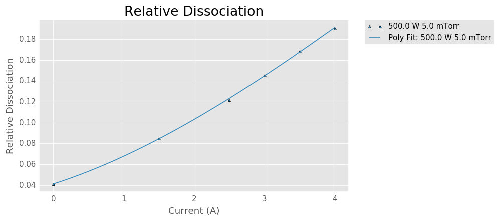

```python
sds.plot_dissociation(fit=True, degree=3)
```

We can also change the independent variable (`ind_var` argument). Alowed values are

```
'current' | 'power' | 'pressure'
```

Of course, the data must agree with the variable chosen.

```python
power_sds = d.SpectrumDataSet('sample_data/power_set_2/')
```

```python
power_sds.compile_dataset()
```

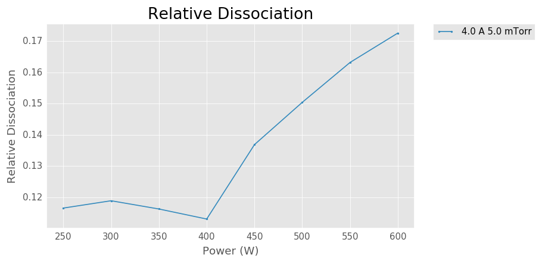

```python
power_sds.plot_dissociation(ind_var='power')
```

#### 3.2 Plotting Multiple Data Sets

This code is only valuable if you can use it to compare spectrum data under different conditions. In order to do that, we need to manually create a matplotlib figure and pass the axes objects to each `SpectrumDataSet`. This is done through the `ax` argument.

**It's a lot easier than that sounds!**

**Note:** we can use the `labeloverride` argument to manually set the legend label

```python
import matplotlib.pyplot as plt
```

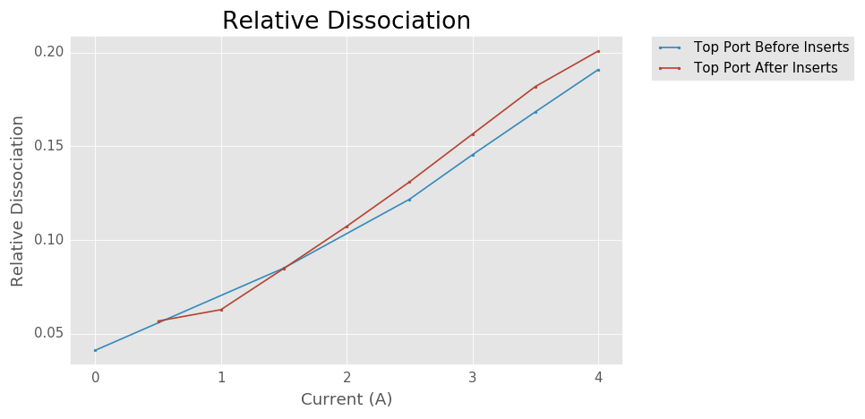

```python
# create the figure
fig = plt.figure()

# get the axes of the blank figure
ax = fig.gca()

# create the data set object and plot on the axes
set1 = d.SpectrumDataSet('sample_data/current_set_1/')
set1.compile_dataset()
set1.plot_dissociation(ax=ax, labeloverride='Top Port Before Inserts')

# create second data set object and plot on the same axes
set2 = d.SpectrumDataSet('sample_data/current_set_2/')
set2.compile_dataset()
set2.plot_dissociation(ax=ax, labeloverride='Top Port After Inserts')
```

- Let me know if you have any questions or suggestions!
- I can add features you think would be helpful and deploy quickly to this server.
- The matplotlib website is very helpful if you want to experiment.

[matplotlib homepage](http://matplotlib.org/index.html)